# Assignment 1: Loess MSE via Bootstrap

Shan Chen

2/21/2020

# Instructions

Recall we used a fixed data set (data.df) and then bootstrapped it to find a MSE for the loess model. In the case in class, we used a fixed value of span (0.75 or so).

Redo the bootstrapped MSE calculation with values of span in the interval (.1,3). Can you settle on a value of the span that minimizes the MSE?

Plan: It might help to write a helper function that will compute the estimated (mean) MSE and variability (variance or sd) as a function of the span. From these, create a plot that shows MSE as a function of span, along with some indication of the variability of the estimate. For example, you should plot mse, mse+2*sd, mse-2*sd all as a function of span.

```r
library(tidyverse)
```

Recall we used a fixed data set (data.df) and then bootstrapped it to find a MSE for the loess model. In the case in class, we used a fixed value of span (0.75 or so).

Replace the underlying function f(x) (=b0+b1*x) with

f(x)= sin(x)-3*cos(3*x)

Generate the data as before…

```r
b0 <- 1
b1 <- 3
##f <- function(x) b0+b1*x
f <- function(x) sin(x)-3*cos(3*x)
```

```r
buildData <- function(N,b0,b1,sigma){
  x <- rnorm(N,0,1)
  y <-f(x)+rnorm(N,0,sigma)
  data.frame(x,y)
}

N <- 50  ##sample size
sigma <- 2.5
data.df <- buildData(N,b0,b1,sigma)
```

Display data

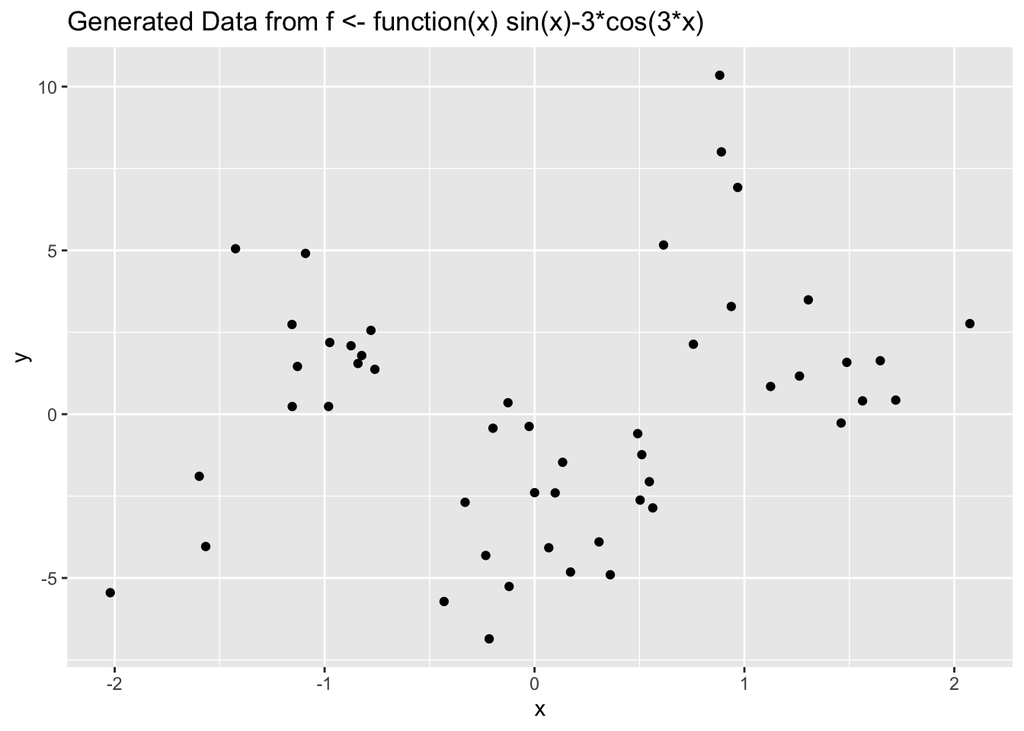

```r
ggplot(data.df)+
    geom_point(aes(x,y))+
  labs(title="Generated Data from f <- function(x) sin(x)-3*cos(3*x)")
```

## Loess model

First build and predict with a loess model to make sure we know how this works. First with a fix span value of 0.25

```r
theSpan <- .25
##theSpan <- 100
mod.lo <- loess(y~x,data=data.df,span=theSpan) ##set up loess
data.df$pred <- predict(mod.lo)
mse <- with(data.df,mean((y-pred)^2)) #calculate mse
```

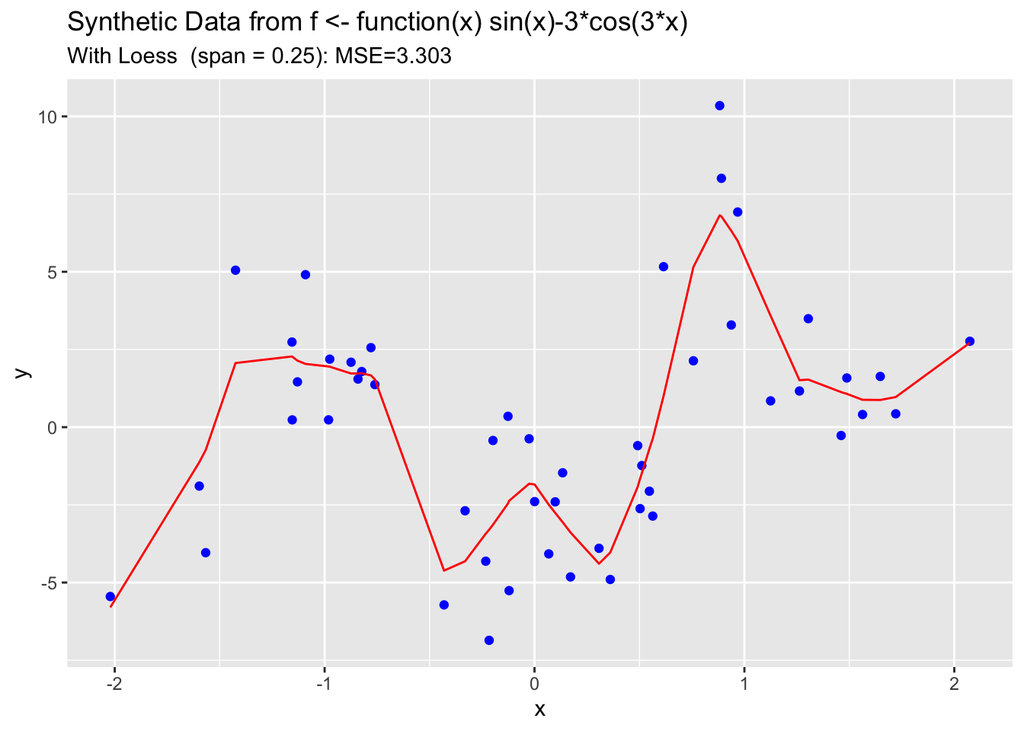

```r
data.df %>%
ggplot()+
    geom_point(aes(x,y),color="blue")+
      geom_line(aes(x,pred),color="red")+
  labs(title="Synthetic Data from f <- function(x) sin(x)-3*cos(3*x)",
       subtitle=sprintf("With Loess  (span = %s): MSE=%s", theSpan,round(mse,3)))
```

# Bootstrapping and generate new testing data

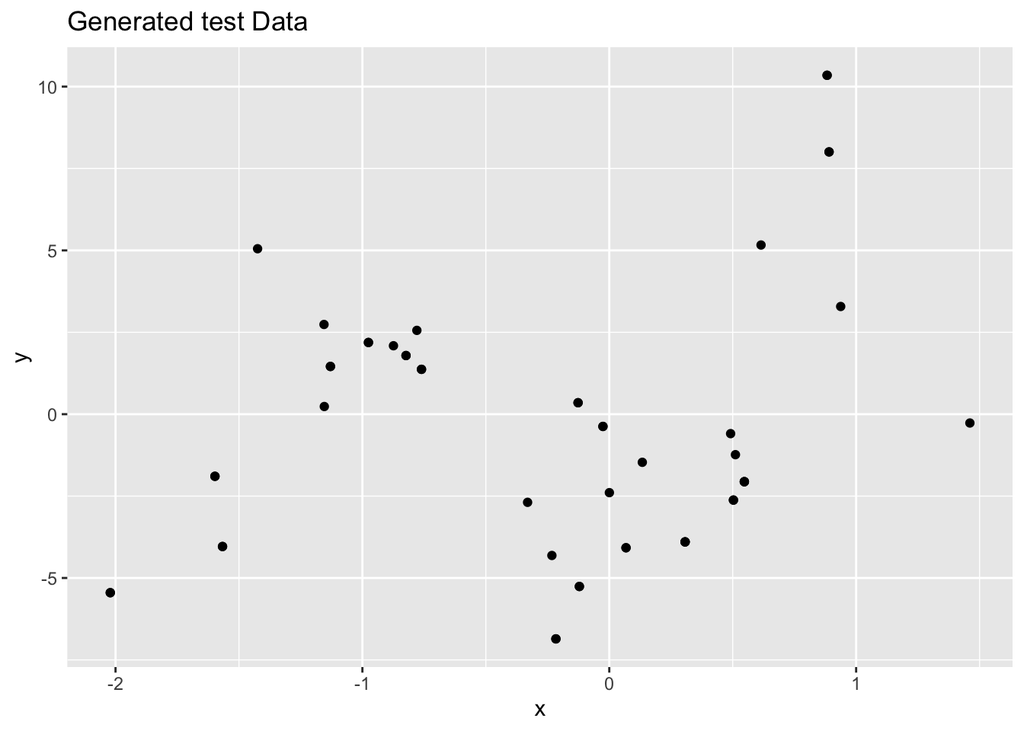

```r
theSpan <- .3
N <- nrow(data.df)
bootSample <- sample(1:N,N,rep=T)
boot.df <- data.df[bootSample,]
#see test data
ggplot(boot.df)+
    geom_point(aes(x,y))+
  labs(title="Generated test Data")
```

```r
#modeling and calculating loses
mod.lo <- loess(y~x,data=data.df,span=theSpan)
boot.df$pred <- predict(mod.lo,newdata=boot.df)
mse.boot <- with(boot.df,mean((y-pred)^2))
c(mse,mse.boot)
```

```
## [1] 3.302725 4.061973
```

These two values should be close. The mse.boot has more validity since we predicted on a different data set from the one on which the model was built. ##But I do not see really close mse honestly.

## Repeat the Bootstrapping 100 times

```r
numBoots <- 100
mseVals <- array(numeric(0),numBoots)
###
for(m in 1:numBoots){
  ## training data
 bootSample <- sample(1:N,N,rep=T)
 train.df <- data.df[bootSample,]
 ## testing data
 bootSample <- sample(1:N,N,rep=T)
 test.df <- data.df[bootSample,]
 ##model and predict
 mod.lo <- loess(y~x,data=train.df,span=.3)
 boot.df$pred <- predict(mod.lo,test.df)
 ##save the mse values
 mseVals[m] <- with(test.df,mean((y-pred)^2))
}
```

Now use the mean and standard deviation as a guage of the MSE estimate.

```r
c(mean(mseVals),sd(mseVals))
```

```
## [1] 3.2889229 0.6388785
```

```r
mseFunc <- function(theSpan,numBoots){
  mseVals <- array(numeric(0),numBoots)
  ###
  m <- 1
  for(m in 1:numBoots){
    ## bootstrap for training data
    bootSample <- sample(1:N,N,rep=T)
    train.df <- data.df[bootSample,]

    ## bootstrap again for testing data
    bootSample <- sample(1:N,N,rep=T)
    test.df <- data.df[bootSample,]
    ##model and predict
    mod.lo <- loess(y~x,data=train.df,span=theSpan)
    test.df$pred <- predict(mod.lo,newdata=test.df)
    test.df$y
    ##save the mse values
    mseVals[m] <- with(test.df,mean((y-pred)^2,na.rm=T))
  }
  # Return the mean and sd of the mseVals
  c(mean(mseVals),sd(mseVals))
  }
```

See result

```r
mseFunc(5,2)
```

```
## [1] 18.421488  3.838066
```

```r
mseFunc(.3,200)
```

```
## [1] 4.586084 1.409390
```

## MSE as a function of span

```r
numSpans <- 100
numBoots <- 200
minSpan <- 0.25
maxSpan <- 2.0
spanVals <- seq(minSpan,maxSpan,length=numSpans)
## store the mean and standard deviation of the mse for each spanVal
spanMSEVals <- matrix(nrow=numSpans,ncol=2)
k <- 1
for(theSpan in spanVals){

  spanMSEVals[k,] <- mseFunc(theSpan,numBoots)
  print(c(theSpan,spanMSEVals[k,1]))
  k <- k+1
}
```

```
## [1] 0.250000 4.878478
## [1] 0.2676768 5.5372189
## [1] 0.2853535 4.7622236
## [1] 0.3030303 4.6810224
## [1] 0.3207071 4.7118428
## [1] 0.3383838 4.4556446
## [1] 0.3560606 4.5816179
## [1] 0.3737374 4.8146565
## [1] 0.3914141 5.0007628
## [1] 0.4090909 5.1517883
## [1] 0.4267677 5.1445215
## [1] 0.4444444 5.2277052
## [1] 0.4621212 5.3958690
## [1] 0.479798 5.368373
## [1] 0.4974747 5.5016525
```

[output cut: 85 more lines]

Display result

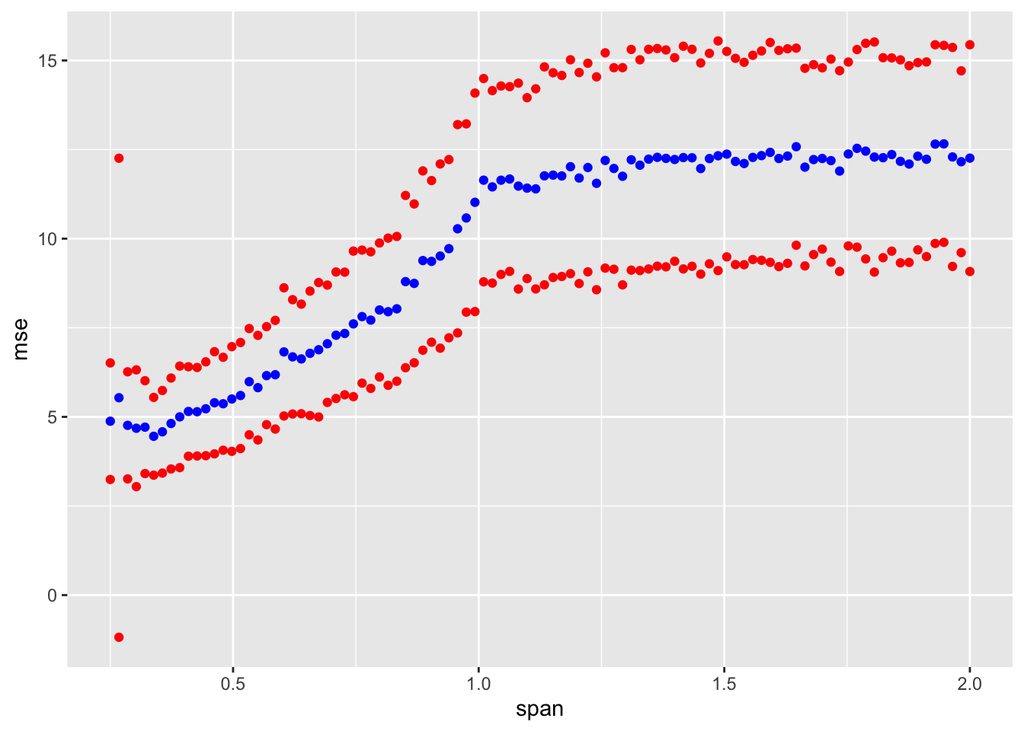

```r
data.frame(span=spanVals,mse=spanMSEVals[,1],sdev=spanMSEVals[,2]) %>%
  ggplot()+
  geom_point(aes(span,mse),color="blue")+
    geom_point(aes(span,mse+sdev),color="red")+
      geom_point(aes(span,mse-sdev),color="red")
```